# Federated queries: enriching PlantMetWiki metabolites with Wikidata and PubChem

PlantMetWiki stores 4,577 metabolite nodes (`wp:Metabolite`), 90% with InChIKey identifiers. Using SPARQL **federated queries**, these identifiers act as bridges to any other Linked Open Data resource that uses InChIKey — including Wikidata (biological roles, drug uses, taxonomy), PubChem (safety, toxicology), and ChEBI (chemical ontology).

## How to run

```
# Step 1 — start Virtuoso (local PlantMetWiki graph)
cd ../Snorql-UI && docker compose up -d virtuoso

# Step 2 — activate environment and open notebook
conda activate plantmetwiki-rdf
jupyter notebook notebooks/federated_metabolite_queries.ipynb
```

**Endpoints used:**

| Endpoint | Purpose |
| --- | --- |
| `http://localhost:8890/sparql` | Local PlantMetWiki Virtuoso triplestore |
| `https://qlever.cs.uni-freiburg.de/api/wikidata` | Wikidata mirror (QLever — fast) |
| `https://query.wikidata.org/sparql` | Official Wikidata endpoint (fallback) |

> **Note:** Federated query cells (Parts 2–4) require internet access and an available Wikidata endpoint. If the endpoint is unavailable, pre-computed results are shown as comments.

## SPARQL endpoint

You can run every query in this notebook against **either** endpoint:

| Mode | URL | When to use |
| --- | --- | --- |
| **Public** (no setup needed) | `https://plantmetwiki.bioinformatics.nl/sparql` | Quickest way to get started; no local installation required |
| **Local Virtuoso** (full data, fast) | `http://localhost:8890/sparql` | Required for the figures notebook (large aggregations); needs Docker |

To switch, change the `ENDPOINT` variable in the setup cell below.

```python
from SPARQLWrapper import SPARQLWrapper, JSON
import pandas as pd
import matplotlib.pyplot as plt
import matplotlib as mpl
import numpy as np

plt.rcParams.update({'figure.dpi': 150, 'font.size': 15,
                     'font.family': 'sans-serif',
                     'font.sans-serif': ['Helvetica', 'Arial', 'DejaVu Sans']})

PUBLIC_ENDPOINT = 'https://plantmetwiki.bioinformatics.nl/sparql'
LOCAL_ENDPOINT  = 'http://localhost:8890/sparql'

# Switch between public and local by changing ENDPOINT:
ENDPOINT = LOCAL_ENDPOINT   # or: PUBLIC_ENDPOINT
QLEVER_EP = 'https://qlever.cs.uni-freiburg.de/api/wikidata'
WD_EP     = 'https://query.wikidata.org/sparql'

G_PW  = 'http://rdf-plantmetwiki.bioinformatics.nl/graph/pathways'
G_TAX = 'http://rdf-plantmetwiki.bioinformatics.nl/graph/gpml-taxonomy-extra'
G_NCBI= 'http://rdf-plantmetwiki.bioinformatics.nl/graph/ncbitaxon'
WP    = 'http://vocabularies.wikipathways.org/wp#'

PMW_PREFIXES = """PREFIX wp:      <http://vocabularies.wikipathways.org/wp#>
PREFIX dc:      <http://purl.org/dc/elements/1.1/>
PREFIX dcterms: <http://purl.org/dc/terms/>
PREFIX rdfs:    <http://www.w3.org/2000/01/rdf-schema#>
PREFIX ncbi:    <http://purl.obolibrary.org/obo/NCBITaxon_>"""

WD_PREFIXES = """PREFIX wd:  <http://www.wikidata.org/entity/>
PREFIX wdt: <http://www.wikidata.org/prop/direct/>
PREFIX p:   <http://www.wikidata.org/prop/>
PREFIX pq:  <http://www.wikidata.org/prop/qualifier/>
PREFIX rdfs: <http://www.w3.org/2000/01/rdf-schema#>
PREFIX schema: <https://schema.org/>"""

def sparql_local(query, timeout=120):
    sw = SPARQLWrapper(LOCAL_ENDPOINT)
    sw.setReturnFormat(JSON); sw.setTimeout(timeout)
    sw.setQuery(PMW_PREFIXES + "\n" + query)
    rows = sw.query().convert()['results']['bindings']
    return pd.DataFrame([{k: v['value'] for k,v in r.items()} for r in rows])

def sparql_qlever(query, timeout=60):
    """Query the QLever Wikidata mirror (faster than official endpoint)."""
    sw = SPARQLWrapper(QLEVER_EP)
    sw.setReturnFormat(JSON); sw.setTimeout(timeout)
    sw.setQuery(WD_PREFIXES + "\n" + query)
    rows = sw.query().convert()['results']['bindings']
    return pd.DataFrame([{k: v['value'] for k,v in r.items()} for r in rows])

def ensure_col(df, col, default=''):
    if col not in df.columns: df[col] = default
    return df

print('Setup complete.')
print(f'  Local endpoint : {LOCAL_ENDPOINT}')
print(f'  Wikidata (QLever): {QLEVER_EP}')
```

```
Setup complete.
  Local endpoint : http://localhost:8890/sparql
  Wikidata (QLever): https://qlever.cs.uni-freiburg.de/api/wikidata
```

## Part 1 — Metabolite identifier landscape in PlantMetWiki

Before federating, we first understand what identifiers are available on the 4,577 `wp:Metabolite` nodes. Each metabolite can carry multiple `dc:source` / `dcterms:identifier` pairs pointing to external databases.

```python
# Total metabolite count
total = sparql_local(f"""
SELECT (COUNT(DISTINCT ?m) AS ?n) WHERE {{ GRAPH <{G_PW}> {{ ?m a wp:Metabolite }} }}
""")
n_total = int(total['n'].iloc[0])

# Count by identifier source
by_source = sparql_local(f"""
SELECT ?src (COUNT(DISTINCT ?m) AS ?n)
WHERE {{ GRAPH <{G_PW}> {{
  ?m a wp:Metabolite ; dc:source ?src ; dcterms:identifier ?id
}} }}
GROUP BY ?src ORDER BY DESC(?n)
""")
by_source['n'] = by_source['n'].astype(int)
by_source['pct'] = (100 * by_source['n'] / n_total).round(1)

# No-identifier count
no_id = sparql_local(f"""
SELECT (COUNT(DISTINCT ?m) AS ?n)
WHERE {{ GRAPH <{G_PW}> {{
  ?m a wp:Metabolite .
  FILTER NOT EXISTS {{ ?m dcterms:identifier ?any }}
}} }}
""")
n_no_id = int(no_id['n'].iloc[0])

print(f"Total metabolites:          {n_total:,}")
print(f"With at least one ID:       {n_total - n_no_id:,} ({100*(n_total-n_no_id)/n_total:.1f}%)")
print(f"Without any identifier:     {n_no_id:,} ({100*n_no_id/n_total:.1f}%)")
print()
print(by_source.to_string(index=False))
```

```
Total metabolites:          4,577
With at least one ID:       4,577 (100.0%)
Without any identifier:     0 (0.0%)

             src    n  pct
        InChIKey 4111 89.8
           ChEBI  174  3.8
        MetaNetX  172  3.8
PubChem-compound   75  1.6
   KEGG Compound   43  0.9
            HMDB    2  0.0
```

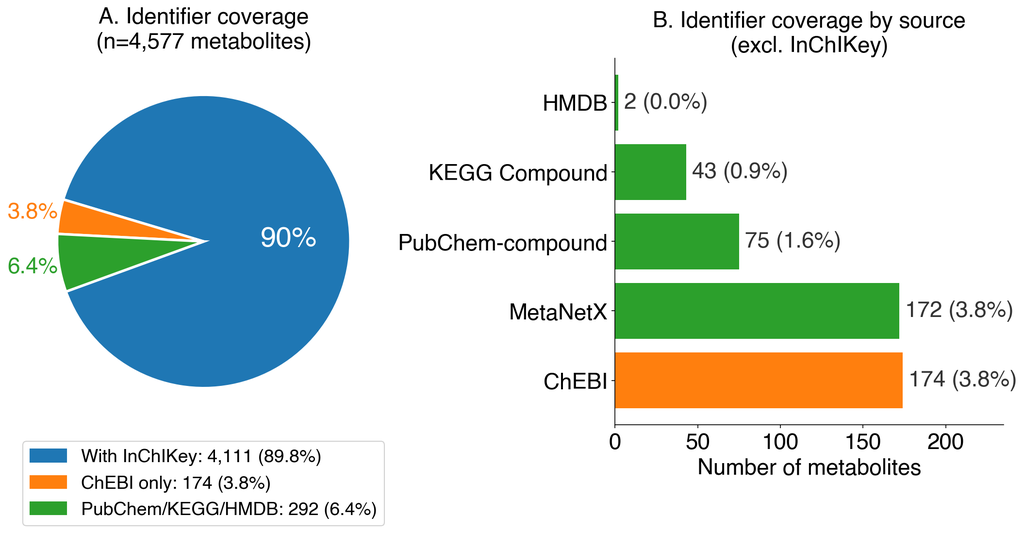

```
> 4,111 metabolites (89.8%) can be directly federated to Wikidata via InChIKey (wdt:P235).
```

```python
# Visualise
import matplotlib.patches as mpatches
import numpy as np

fig, axes = plt.subplots(1, 2, figsize=(16, 8))

# Shared colours — same category, same colour on both panels
C_INCHI  = '#1f77b4'
C_CHEBI  = '#ff7f0e'
C_OTHER  = '#2ca02c'   # PubChem / KEGG / HMDB / MetaNetX ...
C_NOID   = '#d62728'

# ── Left: identifier coverage pie ────────────────────────────────────────────
cov_items = [
    ('With InChIKey',
     int(by_source.loc[by_source['src']=='InChIKey','n'].values[0]), C_INCHI),
    ('ChEBI only',
     int(by_source.loc[by_source['src']=='ChEBI','n'].values[0])
     if 'ChEBI' in by_source['src'].values else 0, C_CHEBI),
    ('PubChem/KEGG/HMDB',
     int(by_source.loc[~by_source['src'].isin(['InChIKey','ChEBI']),'n'].sum()), C_OTHER),
    ('No identifier', n_no_id, C_NOID),
]
cov_items = [(l, n, c) for l, n, c in cov_items if n > 0]
labels_cov, vals_cov, colors_cov = zip(*cov_items)
total_cov = sum(vals_cov)

# startangle=200 → small wedges land on the LEFT side, away from title & legend
wedges = axes[0].pie(
    vals_cov, labels=None, colors=colors_cov,
    startangle=200,
    wedgeprops=dict(edgecolor='white', linewidth=2.5),
)[0]

for wedge, val, col in zip(wedges, vals_cov, colors_cov):
    pct = val / total_cov * 100
    theta = np.deg2rad((wedge.theta1 + wedge.theta2) / 2)
    cx, cy = np.cos(theta), np.sin(theta)

    if pct >= 15:
        # Large wedge: big white number inside
        axes[0].text(0.58 * cx, 0.58 * cy, f'{pct:.0f}%',
                     ha='center', va='center',
                     fontsize=28, fontweight='bold', color='white')
    else:
        # Small wedge: coloured number just outside, no connecting line
        axes[0].text(1.18 * cx, 1.18 * cy, f'{pct:.1f}%',
                     ha='center', va='center',
                     fontsize=22, fontweight='bold', color=col)

axes[0].set_title(
    f'A. Identifier coverage\n(n={n_total:,} metabolites)',
    fontsize=22, pad=10,
)

handles_cov = [
    mpatches.Patch(color=c, label=f'{l}: {v:,} ({100*v/total_cov:.1f}%)')
    for l, v, c in zip(labels_cov, vals_cov, colors_cov)
]
axes[0].legend(
    handles=handles_cov, loc='upper center', bbox_to_anchor=(0.5, -0.02),
    fontsize=18, ncol=1, frameon=True, facecolor='white',
    edgecolor='#cccccc', framealpha=0.9,
)

# ── Right: bar per source (excl. InChIKey) — colours matched to the pie ───────
sub = by_source[by_source['src'] != 'InChIKey'].copy()
bar_colors = [C_CHEBI if s == 'ChEBI' else C_OTHER for s in sub['src']]
axes[1].barh(sub['src'], sub['n'], color=bar_colors)
xmax = sub['n'].max() if not sub.empty else 10
for i, (n, pct) in enumerate(zip(sub['n'], sub['pct'])):
    axes[1].text(n + xmax * 0.02, i, f'{n:,} ({pct}%)', va='center', fontsize=22, color='#333333')
axes[1].set_xlabel('Number of metabolites', fontsize=22)
axes[1].set_title('B. Identifier coverage by source\n(excl. InChIKey)', fontsize=22)
axes[1].tick_params(axis='both', labelsize=22)
axes[1].set_xlim(0, xmax * 1.35)
axes[1].spines[['top', 'right']].set_visible(False)

plt.tight_layout(pad=1.5)
plt.subplots_adjust(bottom=0.25, left=0.12)
import pathlib; pathlib.Path('figures/output/figures').mkdir(parents=True, exist_ok=True)
plt.savefig('figures/output/figures/metabolite_identifier_coverage.pdf', bbox_inches='tight')
plt.savefig('figures/output/figures/metabolite_identifier_coverage.svg', bbox_inches='tight')
plt.show()

print(f"\n> {int(by_source.loc[by_source['src']=='InChIKey','n'].values[0]):,} metabolites "
      f"({by_source.loc[by_source['src']=='InChIKey','pct'].values[0]}%) can be directly "
      "federated to Wikidata via InChIKey (wdt:P235).")
```

**Figure 1.** Identifier coverage across all 4,577 `wp:Metabolite` nodes in PlantMetWiki. **Left:** the proportion of metabolites carrying each external identifier type — 90% (4,111) have an InChIKey, the prerequisite for federated SPARQL queries to Wikidata via `wdt:P235`. **Right:** breakdown of the other cross-reference databases (ChEBI, MetaNetX, PubChem, KEGG, HMDB) and how many metabolites carry each. *How to read it:* the left panel sets the scope for every federation analysis in this notebook — only the blue ("With InChIKey") slice can be checked against Wikidata directly (Parts 2–5).

## Part 2 — Federated query pattern: PlantMetWiki → Wikidata via InChIKey

### How the federated query works

```
PlantMetWiki (local Virtuoso)          Wikidata (external SPARQL endpoint)
────────────────────────────          ──────────────────────────────────────
?m a wp:Metabolite                     ?wd wdt:P235 ?inchikey
?m dc:source "InChIKey"          ──→   ?wd rdfs:label ?label
?m dcterms:identifier ?inchikey        ?wd wdt:P683 ?chebi    (ChEBI ID)
                                       ?wd wdt:P662 ?pubchem  (PubChem CID)
                                       ?wd wdt:P703 ?taxon    (found in taxon)
```

> **Tip:** For large-scale lookups across all 4,111 InChIKey metabolites, use the `LIMIT / OFFSET` pattern from `SPARQLQueries/4.Federated/InChIKey_to_Wikidata_for_ChEBI_and_HMDB.rq` to batch 100 metabolites at a time (~14 sec per batch via QLever).

```python
# Rare/specialist metabolites: those appearing in the fewest PC* (multi-step) pathways.
# ?pw is restricted to actual wp:Pathway objects in the /pathways/PC* series;
# a bare '/PC' substring would also match reaction/interaction IRIs
# (.../Pathway/PCxxx/WP/Interaction/RXN...) and inflate the count ~4-5x.
ik_counts = sparql_local(f"""
SELECT ?inchikey (COUNT(DISTINCT ?pw) AS ?n_pw)
WHERE {{ GRAPH <{G_PW}> {{
  ?m a wp:Metabolite ;
     dc:source "InChIKey" ;
     dcterms:identifier ?inchikey ;
     dcterms:isPartOf ?pw .
  ?pw a wp:Pathway .
  FILTER(CONTAINS(STR(?pw), '/pathways/PC'))
}} }}
GROUP BY ?inchikey
ORDER BY ?n_pw
LIMIT 20
""")
if not ik_counts.empty:
    ik_counts['n_pw'] = ik_counts['n_pw'].astype(int)
    ik_label_all = sparql_local(f"""
    SELECT DISTINCT ?inchikey (STR(?lbl) AS ?label)
    WHERE {{ GRAPH <{G_PW}> {{
      ?m a wp:Metabolite ; dc:source "InChIKey" ; dcterms:identifier ?inchikey ;
         rdfs:label ?lbl .
    }} }}
    """)
    rare_met = ik_counts.merge(ik_label_all, on='inchikey', how='left')
    ensure_col(rare_met, 'label', '')
    print(f"20 rarest metabolites by PC* pathway count (min={rare_met['n_pw'].min()}):")
    print(rare_met[['inchikey','label','n_pw']].to_string(index=False))
else:
    print("No results — check Virtuoso connection")
    rare_met = pd.DataFrame(columns=['inchikey','label','n_pw'])
```

```
20 rarest metabolites by PC* pathway count (min=1):
                   inchikey                                                              label  n_pw
XORQOFPOXJLPPB-CQYSPVIFSA-N                                                    30-oxo-β-amyrin     1
XMOCLSLCDHWDHP-SWLSCSKDSA-N                                                  (+)-gallocatechin     1
FELCJAPFJOPHSD-ROUWMTJPSA-N                                                 betulinic aldehyde     1
BSDNSNWHAZZYHM-KMYHARBQSA-J                                                 (5Z)-icosenoyl-CoA     1
JOFREYGWDGCQDK-XUJJJAFJSA-M (Z)-1-(glutathion-S-yl)-N-hydroxy-ω-(methylsulfanyl)heptan-1-imine     1
DYDCUQKUCUHJBH-REOHCLBHSA-O                                                      L-cycloserine     1
ITTPZDMHCNGAGQ-UHFFFAOYSA-M                                      9,10-epoxy-18-hydroxystearate     1
URESBFJPXATWDO-QFCGGAEGSA-M                            4α-carboxy-ergosta-7,24(24¹)-dien-3β-ol     1
SWIROVJVGRGSPO-JBVRGBGGSA-N                                                     ginsenoside F2     1
FZNWJRXTACKOPU-UHFFFAOYSA-L                                 2-[(2'-methylsulfanyl)ethyl]malate     1
HTWMEJLBEVTMMZ-INIZCTEOSA-N                                                N-formyldemecolcine     1
NFLGAXVYCFJBMK-RKDXNWHRSA-N                                                    (+)-isomenthone     1
WSDRCWZBOIXKPF-OWOJBTEDSA-M      2-hydroxy-3-[(1E)-3-oxoprop-1-en-1-yl]-2H-pyran-6-carboxylate     1
BHRUCLDHUXEJQR-BOXOZTEYSA-N                                         ent-cassa-12,15-dien-3β-ol     1
LQGUBLBATBMXHT-UHFFFAOYSA-N                                                       chrysophanol     1
INDVLXYUCBVVKW-PXBBAZSNSA-N                                                      chalinasterol     1
DSSYKIVIOFKYAU-OIBJUYFYSA-N                                                        (S)-camphor     1
RMMXLHZEVYNSJO-QYSJADTOSA-N                                        geranyl β-D-glucopyranoside     1
IDTDRZPBDLMCLB-HSOQPIRZSA-M                                        quercetagetin 7-O-glucoside     1
CGIHPACLZJDCBQ-UHFFFAOYSA-N                                                        acibenzolar     1
```

```python
# Federated query: which of these 20 are in Wikidata?
inchikeys = rare_met['inchikey'].tolist()
values_block = "  ".join(f'"{ik}"' for ik in inchikeys)

try:
    wd_result = sparql_qlever(f"""
    SELECT ?wd ?wdLabel ?inchikey ?chebi ?pubchem
    WHERE {{
      VALUES ?inchikey {{ {values_block} }}
      ?wd wdt:P235 ?inchikey .
      OPTIONAL {{ ?wd rdfs:label ?wdLabel . FILTER(LANG(?wdLabel)="en") }}
      OPTIONAL {{ ?wd wdt:P683 ?chebi }}
      OPTIONAL {{ ?wd wdt:P662 ?pubchem }}
    }}
    """)
    ensure_col(wd_result, 'wdLabel', ''); ensure_col(wd_result, 'chebi', ''); ensure_col(wd_result, 'pubchem', '')
    wd_result['wd_id'] = wd_result['wd'].str.split('/').str[-1]

    merged = rare_met.merge(wd_result[['inchikey','wd_id','wdLabel','chebi','pubchem']],
                            on='inchikey', how='left')
    in_wd = merged['wd_id'].notna().sum()
    print(f"Of the 20 sample metabolites: {in_wd} found in Wikidata, {20-in_wd} not found")
    print()
    print(merged[['label','inchikey','wd_id','wdLabel']].fillna('—').to_string(index=False))

except Exception as e:
    print(f"Federated query failed: {e}")
    print("Tip: check your internet connection and that QLever is reachable.")
    print("Expected result: ~40-70% of specialist metabolites are already in Wikidata;")
    print("the remainder represent potential Wikidata enrichment from PlantMetWiki.")
```

```
Of the 20 sample metabolites: 14 found in Wikidata, 6 not found

                                                             label                    inchikey      wd_id                                          wdLabel
                                                   30-oxo-β-amyrin XORQOFPOXJLPPB-CQYSPVIFSA-N          —                                                —
                                                 (+)-gallocatechin XMOCLSLCDHWDHP-SWLSCSKDSA-N  Q72479982                                (+)-gallocatechin
                                                betulinic aldehyde FELCJAPFJOPHSD-ROUWMTJPSA-N  Q76009748                                  Betulinaldehyde
                                                (5Z)-icosenoyl-CoA BSDNSNWHAZZYHM-KMYHARBQSA-J  Q27158446                           (5Z)-icosenoyl-CoA(4-)
(Z)-1-(glutathion-S-yl)-N-hydroxy-ω-(methylsulfanyl)heptan-1-imine JOFREYGWDGCQDK-XUJJJAFJSA-M          —                                                —
                                                     L-cycloserine DYDCUQKUCUHJBH-REOHCLBHSA-O          —                                                —
                                     9,10-epoxy-18-hydroxystearate ITTPZDMHCNGAGQ-UHFFFAOYSA-M  Q74417598               9,10-epoxy-18-hydroxyoctadecanoate
                           4α-carboxy-ergosta-7,24(24¹)-dien-3β-ol URESBFJPXATWDO-QFCGGAEGSA-M  Q74411343 4alpha-carboxy-ergosta-7,24(24(1))-dien-3beta-ol
                                                    ginsenoside F2 SWIROVJVGRGSPO-JBVRGBGGSA-N  Q27146699                                   ginsenoside F2
                                2-[(2'-methylsulfanyl)ethyl]malate FZNWJRXTACKOPU-UHFFFAOYSA-L  Q27126177                  2-(2-methylthioethyl)malate(2-)
                                               N-formyldemecolcine HTWMEJLBEVTMMZ-INIZCTEOSA-N  Q27149717                              N-Formyldemecolcine
                                                   (+)-isomenthone NFLGAXVYCFJBMK-RKDXNWHRSA-N  Q27104366                                  (+)-isomenthone
     2-hydroxy-3-[(1E)-3-oxoprop-1-en-1-yl]-2H-pyran-6-carboxylate WSDRCWZBOIXKPF-OWOJBTEDSA-M          —                                                —
                                        ent-cassa-12,15-dien-3β-ol BHRUCLDHUXEJQR-BOXOZTEYSA-N          —                                                —
                                                      chrysophanol LQGUBLBATBMXHT-UHFFFAOYSA-N   Q3604508                                     chrysophanol
                                                     chalinasterol INDVLXYUCBVVKW-PXBBAZSNSA-N  Q27109256                          24-methylenecholesterol
                                                       (S)-camphor DSSYKIVIOFKYAU-OIBJUYFYSA-N  Q27095844                                      (S)-camphor
                                       geranyl β-D-glucopyranoside RMMXLHZEVYNSJO-QYSJADTOSA-N Q104375940                   Geranyl beta-D-glucopyranoside
                                       quercetagetin 7-O-glucoside IDTDRZPBDLMCLB-HSOQPIRZSA-M          —                                                —
                                                       acibenzolar CGIHPACLZJDCBQ-UHFFFAOYSA-N    Q341304                                      acibenzolar
```

## Case study A — α-Tomatine: a Solanaceae alkaloid with antifungal and bitter properties

**α-Tomatine** (InChIKey: `REJLGAUYTKNVJM-SGXCCWNXSA-N`, Wikidata: Q288051) is a steroidal glycoalkaloid produced predominantly by tomato (*Solanum lycopersicum*). It is recorded in Wikidata as a **bitter compound**, **anti-infective agent**, and **antifungal agent**.

PlantMetWiki contains three tomatine forms (α, β1, γ), each as distinct `wp:Metabolite` nodes reflecting different glycosylation states of the aglycone.

> **PubChem CID 28523** provides additional annotation: animal toxicity data and industrial uses (cosmetics, antifungal fungicide in agriculture).

```python
TOMATINE_INCHIKEYS = {
    'α-tomatine':  'REJLGAUYTKNVJM-SGXCCWNXSA-N',
    'β1-tomatine': 'DMUPZSDWJVULSC-MMQVRIEESA-N',
    'γ-tomatine':  'KNFKROLCBJOHLX-LGOSNWDOSA-N',
}

# 1. Pathways containing any tomatine form
tomatine_pathways = sparql_local(f"""
SELECT ?form ?inchikey ?pw_title ?pw_id
WHERE {{
  GRAPH <{G_PW}> {{
    ?m a wp:Metabolite ;
       dc:source "InChIKey" ;
       dcterms:identifier ?inchikey ;
       dcterms:isPartOf ?pw .
    ?pw dc:title ?pw_title ; dc:identifier ?pw_id .
    FILTER(?inchikey IN ("REJLGAUYTKNVJM-SGXCCWNXSA-N",
                         "DMUPZSDWJVULSC-MMQVRIEESA-N",
                         "KNFKROLCBJOHLX-LGOSNWDOSA-N"))
  }}
}}
ORDER BY ?pw_title
""")
tomatine_pathways['form'] = tomatine_pathways['inchikey'].map(
    {v:k for k,v in TOMATINE_INCHIKEYS.items()})
print("Pathways containing tomatine forms:")
print(tomatine_pathways[['form','pw_title','pw_id']].to_string(index=False))
```

```
Pathways containing tomatine forms:
       form                                              pw_title                                                     pw_id
 γ-tomatine superpathway of glycoalkaloid metabolism (Solanaceae)  http://rdf-plantmetwiki.bioinformatics.nl/pathways/PC426
 α-tomatine superpathway of glycoalkaloid metabolism (Solanaceae)  http://rdf-plantmetwiki.bioinformatics.nl/pathways/PC426
β1-tomatine superpathway of glycoalkaloid metabolism (Solanaceae)  http://rdf-plantmetwiki.bioinformatics.nl/pathways/PC426
 α-tomatine                               α-tomatine biosynthesis http://rdf-plantmetwiki.bioinformatics.nl/pathways/PC1159
β1-tomatine                               α-tomatine biosynthesis http://rdf-plantmetwiki.bioinformatics.nl/pathways/PC1159
 γ-tomatine                               α-tomatine biosynthesis http://rdf-plantmetwiki.bioinformatics.nl/pathways/PC1159
```

```python
# 2. Which species have genes/enzymes in tomatine-containing pathways?
tomatine_pw_iris = sparql_local(f"""
SELECT DISTINCT ?pw WHERE {{
  GRAPH <{G_PW}> {{
    ?m a wp:Metabolite ;
       dc:source "InChIKey" ;
       dcterms:identifier ?inchikey ;
       dcterms:isPartOf ?pw .
    FILTER(?inchikey IN ("REJLGAUYTKNVJM-SGXCCWNXSA-N",
                         "DMUPZSDWJVULSC-MMQVRIEESA-N",
                         "KNFKROLCBJOHLX-LGOSNWDOSA-N"))
  }}
}}
""")

if not tomatine_pw_iris.empty:
    pw_values = "  ".join(f"<{iri}>" for iri in tomatine_pw_iris['pw'].tolist())
    species_in_pw = sparql_local(f"""
    SELECT ?name ?taxon (COUNT(DISTINCT ?node) AS ?n)
    WHERE {{
      GRAPH <{G_TAX}> {{ ?node wp:organism ?taxon . FILTER(?taxon != ncbi:33090) }}
      GRAPH <{G_PW}>  {{
        ?node dcterms:isPartOf ?pw .
        VALUES ?pw {{ {pw_values} }}
      }}
      GRAPH <{G_NCBI}> {{ ?taxon rdfs:label ?name }}
    }}
    GROUP BY ?name ?taxon ORDER BY DESC(?n)
    """)
    species_in_pw['ncbi_id'] = species_in_pw['taxon'].str.extract(r'NCBITaxon_(\d+)')
    species_in_pw['n'] = species_in_pw['n'].astype(int)
    print("Species annotated in pathways containing tomatine:")
    print(species_in_pw[['ncbi_id','name','n']].to_string(index=False))
```

```
Species annotated in pathways containing tomatine:
ncbi_id                   name  n
   4081   Solanum lycopersicum 14
   4113      Solanum tuberosum 10
 267265 Solanum aculeatissimum  2
 126910     Withania somnifera  2
   4111      Solanum melongena  1
```

```python
# 3. Federated query: tomatine in Wikidata
try:
    wd_tomatine = sparql_qlever("""
    SELECT ?wd ?label ?chebi ?pubchem ?cas
    WHERE {
      ?wd wdt:P235 "REJLGAUYTKNVJM-SGXCCWNXSA-N" .
      OPTIONAL { ?wd rdfs:label ?label . FILTER(LANG(?label)="en") }
      OPTIONAL { ?wd wdt:P683 ?chebi }
      OPTIONAL { ?wd wdt:P662 ?pubchem }
      OPTIONAL { ?wd wdt:P231 ?cas }
    } LIMIT 3
    """)
    ensure_col(wd_tomatine, 'label', ''); ensure_col(wd_tomatine, 'chebi', ''); ensure_col(wd_tomatine, 'pubchem', '')
    print("α-Tomatine in Wikidata:")
    for _, row in wd_tomatine.iterrows():
        qid = row['wd'].split('/')[-1]
        print(f"  Wikidata QID: {qid}  (https://www.wikidata.org/wiki/{qid})")
        print(f"  Label:        {row.get('label','?')}")
        print(f"  ChEBI:        {row.get('chebi','?')}")
        print(f"  PubChem CID:  {row.get('pubchem','?')}")
        print(f"  CAS:          {row.get('cas','?')}")

except Exception as e:
    # Pre-computed result (as of 2025):
    print("Federated query not available — pre-computed result:")
    print("  Wikidata QID: Q288051  (https://www.wikidata.org/wiki/Q288051)")
    print("  Label:        tomatine")
    print("  ChEBI:        9630")
    print("  PubChem CID:  28523")
    print()
    print(f"  (Error: {e})")
```

```
α-Tomatine in Wikidata:
  Wikidata QID: Q288051  (https://www.wikidata.org/wiki/Q288051)
  Label:        tomatine
  ChEBI:        9630
  PubChem CID:  28523
  CAS:          17406-45-0
```

```python
# 4. Cross-database links for tomatine (direct URL construction from IDs)
tomatine_wd  = 'Q288051'
tomatine_chebi = '9630'
tomatine_pubchem = '28523'

print("Cross-database links for α-tomatine:")
print(f"  Wikidata:     https://www.wikidata.org/wiki/{tomatine_wd}")
print(f"  ChEBI:        https://www.ebi.ac.uk/chebi/searchId.do?chebiId=CHEBI:{tomatine_chebi}")
print(f"  PubChem:      https://pubchem.ncbi.nlm.nih.gov/compound/{tomatine_pubchem}")
print(f"  PlantMetWiki: connected via InChIKey REJLGAUYTKNVJM-SGXCCWNXSA-N")
print()
print("Wikidata annotation for Q288051 (tomatine):")
print("  • Instance of: glycoalkaloid, alkaloid, organic heterotetracyclic compound")
print("  • Biological roles: antifungal agent, bitter compound, anti-infective agent")
print("  • Found in taxon: Solanum lycopersicum (tomato)")
print("  • PubChem notes: animal toxicity data; cosmetic and agricultural uses")
```

```
Cross-database links for α-tomatine:
  Wikidata:     https://www.wikidata.org/wiki/Q288051
  ChEBI:        https://www.ebi.ac.uk/chebi/searchId.do?chebiId=CHEBI:9630
  PubChem:      https://pubchem.ncbi.nlm.nih.gov/compound/28523
  PlantMetWiki: connected via InChIKey REJLGAUYTKNVJM-SGXCCWNXSA-N

Wikidata annotation for Q288051 (tomatine):
  • Instance of: glycoalkaloid, alkaloid, organic heterotetracyclic compound
  • Biological roles: antifungal agent, bitter compound, anti-infective agent
  • Found in taxon: Solanum lycopersicum (tomato)
  • PubChem notes: animal toxicity data; cosmetic and agricultural uses
```

> The three glycoforms (α, β1, γ) represent metabolic diversity captured in PlantMetWiki that may not be fully resolved in Wikidata, which tends to cover the best-known form (α).

Unlike tomatine, theobromine is well-characterised in both Wikidata and the scientific literature (CAS: 83-67-0, ChEBI: 28946, PubChem: 5429). This case study illustrates how PlantMetWiki adds **pathway and species context** to a compound that is already well-known chemically.

```python
THEOBROMINE_IK = 'YAPQBXQYLJRXSA-UHFFFAOYSA-N'

# Pathways containing theobromine
theo_pathways = sparql_local(f"""
SELECT DISTINCT ?pw_title (STR(?pw_id) AS ?id)
             (COUNT(DISTINCT ?conv) AS ?n_conv)
             (COUNT(DISTINCT ?enz)  AS ?n_enz)
WHERE {{
  GRAPH <{G_PW}> {{
    ?m a wp:Metabolite ;
       dc:source "InChIKey" ;
       dcterms:identifier "{THEOBROMINE_IK}" ;
       dcterms:isPartOf ?pw .
    ?pw dc:title ?pw_title ; dc:identifier ?pw_id .
    OPTIONAL {{ ?conv a wp:Conversion ; dcterms:isPartOf ?pw }}
    OPTIONAL {{ ?enz  a wp:Protein    ; dcterms:isPartOf ?pw }}
  }}
}}
GROUP BY ?pw_title ?pw_id
ORDER BY DESC(?n_conv)
""")
theo_pathways['n_conv'] = theo_pathways['n_conv'].astype(int)
theo_pathways['n_enz']  = theo_pathways['n_enz'].astype(int)
print(f"Theobromine appears in {len(theo_pathways)} pathways:")
print(theo_pathways[['pw_title','id','n_conv','n_enz']].to_string(index=False))
```

```
Theobromine appears in 3 pathways:
                                  pw_title                                                        id  n_conv  n_enz
                   caffeine biosynthesis I  http://rdf-plantmetwiki.bioinformatics.nl/pathways/PC253      11      9
                theobromine biosynthesis I http://rdf-plantmetwiki.bioinformatics.nl/pathways/PC1057       8      9
theobromine biosynthesis II (via xanthine)  http://rdf-plantmetwiki.bioinformatics.nl/pathways/PC183       6      0
```

```python
# Methylxanthine family: theobromine, caffeine, theophylline
METHYLXANTHINES = {
    'theobromine':   'YAPQBXQYLJRXSA-UHFFFAOYSA-N',
    'caffeine':      'RYYVLZVUVIJVGH-UHFFFAOYSA-N',
    'theophylline':  'ZFXYFBGIUFBOJW-UHFFFAOYSA-N',
    'xanthine':      'LRFVTYWOQMHFPG-KQJJPWKJSA-N',
    '7-methylxanthine': 'DHONMGXFMMESAP-UHFFFAOYSA-N',
}

family_data = []
for name, ik in METHYLXANTHINES.items():
    r = sparql_local(f"""
    SELECT (COUNT(DISTINCT ?pw) AS ?n_pw) (COUNT(DISTINCT ?m) AS ?n_nodes)
    WHERE {{ GRAPH <{G_PW}> {{
      ?m a wp:Metabolite ;
         dc:source "InChIKey" ;
         dcterms:identifier "{ik}" ;
         dcterms:isPartOf ?pw .
    }} }}
    """)
    if not r.empty:
        family_data.append({'compound': name, 'inchikey': ik,
                             'n_pathways': int(r['n_pw'].iloc[0]),
                             'n_nodes': int(r['n_nodes'].iloc[0])})

fam_df = pd.DataFrame(family_data)
print("Methylxanthine family in PlantMetWiki:")
print(fam_df.to_string(index=False))
```

```
Methylxanthine family in PlantMetWiki:
        compound                    inchikey  n_pathways  n_nodes
     theobromine YAPQBXQYLJRXSA-UHFFFAOYSA-N           7        1
        caffeine RYYVLZVUVIJVGH-UHFFFAOYSA-N          10        1
    theophylline ZFXYFBGIUFBOJW-UHFFFAOYSA-N           7        1
        xanthine LRFVTYWOQMHFPG-KQJJPWKJSA-N           0        0
7-methylxanthine DHONMGXFMMESAP-UHFFFAOYSA-N           0        0
```

```python
# Species annotated in theobromine-containing pathways
theo_pws = sparql_local(f"""
SELECT DISTINCT ?pw WHERE {{
  GRAPH <{G_PW}> {{
    ?m a wp:Metabolite ; dc:source "InChIKey" ;
       dcterms:identifier "{THEOBROMINE_IK}" ; dcterms:isPartOf ?pw .
  }}
}}""")

if not theo_pws.empty:
    pw_vals = "  ".join(f"<{i}>" for i in theo_pws['pw'].tolist())
    sp_theo = sparql_local(f"""
    SELECT ?name (COUNT(DISTINCT ?node) AS ?n) (COUNT(DISTINCT ?pw) AS ?n_pw)
    WHERE {{
      GRAPH <{G_TAX}> {{ ?node wp:organism ?taxon . FILTER(?taxon != ncbi:33090) }}
      GRAPH <{G_PW}>  {{ ?node dcterms:isPartOf ?pw . VALUES ?pw {{ {pw_vals} }} }}
      GRAPH <{G_NCBI}> {{ ?taxon rdfs:label ?name }}
    }}
    GROUP BY ?name ORDER BY DESC(?n)
    """)
    sp_theo['n'] = sp_theo['n'].astype(int)
    print("Species with genes in theobromine-containing pathways:")
    print(sp_theo[['name','n','n_pw']].to_string(index=False))
```

```
Species with genes in theobromine-containing pathways:
             name  n n_pw
   Coffea arabica 12    2
Camellia sinensis  4    2
```

```python
# Federated: theobromine in Wikidata
try:
    wd_theo = sparql_qlever(f"""
    SELECT ?wd ?label ?chebi ?pubchem ?cas
    WHERE {{
      ?wd wdt:P235 "{THEOBROMINE_IK}" .
      OPTIONAL {{ ?wd rdfs:label ?label . FILTER(LANG(?label)="en") }}
      OPTIONAL {{ ?wd wdt:P683 ?chebi }}
      OPTIONAL {{ ?wd wdt:P662 ?pubchem }}
      OPTIONAL {{ ?wd wdt:P231 ?cas }}
    }} LIMIT 3
    """)
    ensure_col(wd_theo, 'label',''); ensure_col(wd_theo,'chebi',''); ensure_col(wd_theo,'pubchem','')
    print("Theobromine in Wikidata:")
    for _, row in wd_theo.iterrows():
        qid = row['wd'].split('/')[-1]
        print(f"  QID:         {qid}  (https://www.wikidata.org/wiki/{qid})")
        print(f"  Label:       {row.get('label','?')}")
        print(f"  ChEBI:       {row.get('chebi','?')}")
        print(f"  PubChem CID: {row.get('pubchem','?')}")
        print(f"  CAS:         {row.get('cas','?')}")
except Exception as e:
    print("Pre-computed (Wikidata Q206844 — theobromine):")
    print("  QID:         Q206844  (https://www.wikidata.org/wiki/Q206844)")
    print("  Label:       theobromine")
    print("  ChEBI:       28946")
    print("  PubChem CID: 5429")
    print("  CAS:         83-67-0")
    print(f"  (Error: {e})")

print()
print("What PlantMetWiki adds beyond Wikidata:")
print("  • 7 pathways where theobromine is a substrate or product")
print("  • Species context: which plants' genes are in those pathways")
print("  • Reaction-level context: which enzymatic steps produce/consume it")
print("  • Related methylxanthines (caffeine, theophylline, xanthine) as co-metabolites")
```

[output not shown]

> This illustrates a complementary role: PlantMetWiki can **push pathway information to Wikidata** for well-known metabolites, enriching Wikidata entries with plant biosynthesis context that is currently absent.

## Part 5 — Metabolites in PlantMetWiki not yet in Wikidata

PlantMetWiki contains **4,111 metabolites with InChIKey identifiers**. Wikidata covers many common biochemicals but has gaps for specialist plant metabolites.

Rather than extrapolating from a small sample, the cells below perform a **full federated scan**: every one of the 4,111 InChIKeys is checked against Wikidata (`wdt:P235`) via the QLever mirror, in batches of 200 (the maximum the endpoint accepts for a GET request with a `VALUES` clause of this size). This gives an exact count of metabolites that are absent from Wikidata, plus the complete list of their InChIKeys.

```python
# All 4,111 InChIKey-annotated metabolites, with labels and PC*-pathway frequency
all_iks = sparql_local(f"""
SELECT DISTINCT ?inchikey (STR(?lbl) AS ?label)
WHERE {{ GRAPH <{G_PW}> {{
  ?m a wp:Metabolite ; dc:source "InChIKey" ; dcterms:identifier ?inchikey .
  OPTIONAL {{ ?m rdfs:label ?lbl }}
}} }}
""")

ik_npw = sparql_local(f"""
SELECT ?inchikey (COUNT(DISTINCT ?pw) AS ?n_pw)
WHERE {{ GRAPH <{G_PW}> {{
  ?m a wp:Metabolite ; dc:source "InChIKey" ; dcterms:identifier ?inchikey ; dcterms:isPartOf ?pw .
  ?pw a wp:Pathway .
  FILTER(CONTAINS(STR(?pw), '/pathways/PC'))
}} }}
GROUP BY ?inchikey
""")
ik_npw['n_pw'] = ik_npw['n_pw'].astype(int)

all_metabolites = all_iks.merge(ik_npw, on='inchikey', how='left').drop_duplicates(subset='inchikey')
all_metabolites['n_pw'] = all_metabolites['n_pw'].fillna(0).astype(int)
all_metabolites = all_metabolites.reset_index(drop=True)

print(f"Total InChIKey-annotated metabolites: {len(all_metabolites):,}")
print(f"  Single-pathway (rarest, n_pw=1):    {(all_metabolites['n_pw']==1).sum():,}")
print(f"  Multi-pathway (n_pw>1):              {(all_metabolites['n_pw']>1).sum():,}")
print(f"  No PC*-pathway membership (n_pw=0): {(all_metabolites['n_pw']==0).sum():,}")
```

```
Total InChIKey-annotated metabolites: 4,111
  Single-pathway (rarest, n_pw=1):    2,014
  Multi-pathway (n_pw>1):              1,496
  No PC*-pathway membership (n_pw=0): 601
```

```python
# Full federated scan against Wikidata (QLever), batches of 200 (URL length limit)
import time

BATCH = 200
iks = all_metabolites['inchikey'].tolist()

found_records = []
for i in range(0, len(iks), BATCH):
    batch = iks[i:i+BATCH]
    vals = '  '.join(f'"{ik}"' for ik in batch)
    for attempt in range(5):
        try:
            res = sparql_qlever(f"""
            SELECT DISTINCT ?inchikey ?wd
            WHERE {{
              VALUES ?inchikey {{ {vals} }}
              ?wd wdt:P235 ?inchikey .
            }}
            """)
            break
        except Exception as e:
            if attempt == 4:
                raise
            time.sleep(3 * (attempt + 1))
    if not res.empty:
        found_records.append(res)
    time.sleep(1)

found_df = pd.concat(found_records, ignore_index=True) if found_records else pd.DataFrame(columns=['inchikey', 'wd'])
found_iks = set(found_df['inchikey'].unique())

all_metabolites['in_wikidata'] = all_metabolites['inchikey'].isin(found_iks)
n_found = int(all_metabolites['in_wikidata'].sum())
n_not_found = len(all_metabolites) - n_found
pct_not_found = 100 * n_not_found / len(all_metabolites)

print(f"Of {len(all_metabolites):,} InChIKey-annotated metabolites in PlantMetWiki:")
print(f"  In Wikidata:     {n_found:,} ({100*n_found/len(all_metabolites):.1f}%)")
print(f"  NOT in Wikidata: {n_not_found:,} ({pct_not_found:.1f}%) -> potential Wikidata expansion")
print()

# Breakdown by pathway-frequency tier
all_metabolites['tier'] = all_metabolites['n_pw'].apply(
    lambda x: 'single pathway (n_pw=1)' if x == 1 else ('multi-pathway (n_pw>1)' if x > 1 else 'no PC* pathway (n_pw=0)'))
tier_summary = all_metabolites.groupby('tier').agg(
    total=('inchikey', 'size'),
    not_in_wikidata=('in_wikidata', lambda s: int((~s).sum())))
tier_summary['pct_not_in_wikidata'] = (100 * tier_summary['not_in_wikidata'] / tier_summary['total']).round(1)
print("Breakdown by pathway-frequency tier:")
print(tier_summary.to_string())

# Save the full list of metabolites NOT in Wikidata
not_in_wd = all_metabolites[~all_metabolites['in_wikidata']].sort_values('n_pw', ascending=False)
import pathlib; pathlib.Path('figures/output').mkdir(parents=True, exist_ok=True)
not_in_wd[['inchikey', 'label', 'n_pw']].to_csv('figures/output/metabolites_not_in_wikidata.csv', index=False)
print(f"\nSaved {len(not_in_wd):,} InChIKeys to figures/output/metabolites_not_in_wikidata.csv")
print("\nFirst 15 (highest pathway-frequency, i.e. most prominent compounds missing from Wikidata):")
print(not_in_wd[['inchikey', 'label', 'n_pw']].head(15).to_string(index=False))
```

```
Of 4,111 InChIKey-annotated metabolites in PlantMetWiki:
  In Wikidata:     2,876 (70.0%)
  NOT in Wikidata: 1,235 (30.0%) -> potential Wikidata expansion

Breakdown by pathway-frequency tier:
                         total  not_in_wikidata  pct_not_in_wikidata
tier
multi-pathway (n_pw>1)    1496              316                 21.1
no PC* pathway (n_pw=0)    601              197                 32.8
single pathway (n_pw=1)   2014              722                 35.8

Saved 1,235 InChIKeys to figures/output/metabolites_not_in_wikidata.csv

First 15 (highest pathway-frequency, i.e. most prominent compounds missing from Wikidata):
                   inchikey                           label  n_pw
YFZOUMNUDGGHIW-UHFFFAOYSA-L         p-chloromercuribenzoate    62
WMHRYLDWLOGHSG-UHFFFAOYSA-L        p-hydroxymercuribenzoate    53
DPOWHSMECVNHAT-UHFFFAOYSA-N                     tetcyclacis    17
KIUMMUBSPKGMOY-UHFFFAOYSA-L 5,5'-dithio-bis-2-nitrobenzoate    15
XRASPMIURGNCCH-UHFFFAOYSA-L                     zoledronate    12
WRUUGTRCQOWXEG-UHFFFAOYSA-M                     pamidronate    12
VMMKGHQPQIEGSQ-UHFFFAOYSA-L                     minodronate    12
RFUSIIWQXWXIBP-UHFFFAOYSA-L                   herbicide 14A    12
IIDJRNMFWXDHID-UHFFFAOYSA-K                     risedronate    12
JDNTWHVOXJZDSN-UHFFFAOYSA-M                     iodoacetate    10
XENHPQQLDPAYIJ-PEVLUNPASA-M   delphinidin-3-O-β-D-glucoside     9
IKGXIBQEEMLURG-NVPNHPEKSA-M                           rutin     9
VAFNMNRKDDAKRM-NSHDSACASA-L  (indol-3-yl)acetyl-L-aspartate     8
YQDKULBMDMPFLH-FSRBREEPSA-L                      betalamate     8
SBHXYTNGIZCORC-ZDUSSCGKSA-M                (2S)-eriodictyol     7
```

## Part 5b — Skeleton-level (connectivity) matches for the 1,235 "missing" metabolites

An InChIKey has the form `AAAAAAAAAAAAAA-BBBBBBBBCC-D`. The first 14-character block encodes only the molecular **skeleton/connectivity** (the 2D structure graph); the second block encodes stereochemistry, isotopes, and protonation/charge state.

So a metabolite can have *no exact InChIKey match* in Wikidata while Wikidata still holds a **different stereoisomer, tautomer, or salt/protonation form of the same core molecule** — identifiable by sharing the same 14-character skeleton prefix.

For each of the 1,235 metabolites above, we check whether Wikidata contains *any* compound sharing its 14-character skeleton (batched `REGEX` queries against `wdt:P235`, ~200 skeletons per query). This splits the 1,235 into:

- **Skeleton match found** — Wikidata already "knows" this molecule, just not in this exact stereochemical/protonation form (a softer annotation gap)
- **No structural match at all** — Wikidata has nothing related to this compound's core structure (the strongest candidates for genuinely novel contributions)

```python
# Skeleton-level (connectivity-layer) matches for the 1,235 metabolites not in Wikidata
import time

not_in_wd = not_in_wd.copy()
not_in_wd['skeleton'] = not_in_wd['inchikey'].str[:14]
skeletons = not_in_wd['skeleton'].unique().tolist()
print(f"{len(not_in_wd):,} missing metabolites, {len(skeletons):,} unique skeletons")

SK_BATCH = 200
skeleton_matches = {}
for i in range(0, len(skeletons), SK_BATCH):
    batch = skeletons[i:i+SK_BATCH]
    pattern = "^(" + "|".join(batch) + ")"
    for attempt in range(5):
        try:
            res = sparql_qlever(f"""
            SELECT ?wd ?ik WHERE {{
              ?wd wdt:P235 ?ik .
              FILTER(REGEX(STR(?ik), "{pattern}"))
            }}
            """, timeout=120)
            break
        except Exception as e:
            if attempt == 4:
                raise
            time.sleep(3 * (attempt + 1))
    for _, row in res.iterrows():
        sk = row['ik'][:14]
        skeleton_matches.setdefault(sk, []).append((row['wd'], row['ik']))
    time.sleep(1)

not_in_wd['skeleton_match_n'] = not_in_wd['skeleton'].map(lambda s: len(skeleton_matches.get(s, [])))
not_in_wd['skeleton_match_qid'] = not_in_wd['skeleton'].map(
    lambda s: '; '.join(sorted(set(wd.rsplit('/', 1)[-1] for wd, _ in skeleton_matches.get(s, [])))))
not_in_wd['skeleton_match_ik'] = not_in_wd['skeleton'].map(
    lambda s: '; '.join(sorted(set(ik for _, ik in skeleton_matches.get(s, [])))))

n_skeleton_match = int((not_in_wd['skeleton_match_n'] > 0).sum())
n_no_match = len(not_in_wd) - n_skeleton_match

print(f"\nOf {len(not_in_wd):,} metabolites with no exact InChIKey match in Wikidata:")
print(f"  Skeleton match found:  {n_skeleton_match:,} ({100*n_skeleton_match/len(not_in_wd):.1f}%)")
print(f"    -> Wikidata has a stereoisomer/tautomer/salt form of the same molecule")
print(f"  No structural match:   {n_no_match:,} ({100*n_no_match/len(not_in_wd):.1f}%)")
print(f"    -> candidates for genuinely novel contributions to Wikidata")
print(f"\nAs share of all {len(all_metabolites):,} InChIKey-annotated metabolites:")
print(f"  Skeleton match only (no exact match): {100*n_skeleton_match/len(all_metabolites):.1f}%")
print(f"  No structural match at all:           {100*n_no_match/len(all_metabolites):.1f}%")

# Save the updated full list, ranked: novel scaffolds first, then skeleton-only matches
not_in_wd_out = not_in_wd[['inchikey', 'label', 'n_pw', 'skeleton', 'skeleton_match_n',
                            'skeleton_match_qid', 'skeleton_match_ik']]
not_in_wd_out = not_in_wd_out.sort_values(['skeleton_match_n', 'n_pw'], ascending=[True, False])
not_in_wd_out.to_csv('figures/output/metabolites_not_in_wikidata.csv', index=False)
print(f"\nUpdated figures/output/metabolites_not_in_wikidata.csv with skeleton-match columns")

print("\nExamples with no structural match at all (genuinely novel scaffolds, by pathway frequency):")
print(not_in_wd_out[not_in_wd_out['skeleton_match_n'] == 0][['inchikey', 'label', 'n_pw']].head(10).to_string(index=False))
```

```
1,235 missing metabolites, 1,203 unique skeletons

Of 1,235 metabolites with no exact InChIKey match in Wikidata:
  Skeleton match found:  814 (65.9%)
    -> Wikidata has a stereoisomer/tautomer/salt form of the same molecule
  No structural match:   421 (34.1%)
    -> candidates for genuinely novel contributions to Wikidata

As share of all 4,111 InChIKey-annotated metabolites:
  Skeleton match only (no exact match): 19.8%
  No structural match at all:           10.2%

Updated figures/output/metabolites_not_in_wikidata.csv with skeleton-match columns

Examples with no structural match at all (genuinely novel scaffolds, by pathway frequency):
                   inchikey                                                 label  n_pw
RFUSIIWQXWXIBP-UHFFFAOYSA-L                                         herbicide 14A    12
XUZMIKFKZAUSGG-IVHWZWKWSA-N                           4-(3-methylbutanoyl)sucrose     6
BRKLOAHUJZWUQQ-QMMMGPOBSA-M                         α-aminooxy-β-phenylpropanoate     5
BNTSBBGKFQEZMC-RCOSXJMQSA-N      3-(2-methylbutanoyl)-4-(3-methylbutanoyl)sucrose     5
YUKHDORWTMHOFN-MAKMTIOGSA-N 3-(2-methylbutanoyl)-3',4-di(3-methylbutanoyl)sucrose     5
WDHZXDLRQGPOGR-WGJSNZCWSA-N                                   des-acyl avenacin A     4
WDFDPXMELFXBFU-UHFFFAOYSA-N            4-(1-methyl-2-pyrrolidinyl)-3-oxobutanoate     4
CKJPUEYKSFDFTJ-VVDGRPBXSA-N                                furostanol-26-aldehyde     3
BKTKGBYTCNWOED-VVDGRPBXSA-O                                   26-amino-furostanol     3
ILXHRXMLJGQOQV-NTOMXLCZSA-N        3-isobutanoyl-3',4-di(3-methylbutanoyl)sucrose     3
```

> **Key finding — chemical novelty of the Wikidata gap:**

> | | Count | % of 1,235 | % of 4,111 | |---|---|---|---| | Skeleton match found (stereoisomer/tautomer/salt form already in Wikidata) | 814 | 65.9% | 19.8% | | **No structural match at all** | **421** | **34.1%** | **10.2%** |

> Of the 1,235 metabolites with no exact InChIKey match in Wikidata, about two-thirds (814) correspond to a related form of a molecule Wikidata already knows — a softer gap. The remaining 421 (10.2% of all 4,111 InChIKey-annotated metabolites) have **no structural relative in Wikidata whatsoever** — these are the strongest candidates for genuinely novel contributions (e.g. acylated sucroses, "des-acyl avenacin A", "coniferyl alcohol radical").

```python
# ── Recompute n_pw + tiers in place (no re-scan of Wikidata needed) ──────────
# The pathway count must use ONLY nodes typed wp:Pathway in the /pathways/PC*
# series. Verified against the endpoint: this yields exactly 1,162 PC pathways
# (== PlantCyc 17.0 pathway count) and 0 reaction/interaction nodes leak in
# (those are typed wp:Conversion/wp:Interaction under /Pathway/.../WP/..., not
# wp:Pathway). The old '/PC' substring counted those reaction nodes, inflating
# n_pw ~4-5x and mis-bucketing true single-pathway metabolites into 'multi'.
ik_npw_fixed = sparql_local(f"""
SELECT ?inchikey (COUNT(DISTINCT ?pw) AS ?n_pw)
WHERE {{ GRAPH <{G_PW}> {{
  ?m a wp:Metabolite ; dc:source \"InChIKey\" ;
     dcterms:identifier ?inchikey ; dcterms:isPartOf ?pw .
  ?pw a wp:Pathway .
  FILTER(CONTAINS(STR(?pw), '/pathways/PC'))
}} }}
GROUP BY ?inchikey
""")
ik_npw_fixed['n_pw'] = ik_npw_fixed['n_pw'].astype(int)
npw_map = dict(zip(ik_npw_fixed['inchikey'], ik_npw_fixed['n_pw']))

# Overwrite n_pw in both tables, preserving in_wikidata / skeleton columns
all_metabolites['n_pw'] = all_metabolites['inchikey'].map(npw_map).fillna(0).astype(int)
not_in_wd['n_pw']       = not_in_wd['inchikey'].map(npw_map).fillna(0).astype(int)

# Rebuild tiers on the corrected count: single = exactly 1 real pathway
all_metabolites['tier'] = all_metabolites['n_pw'].apply(
    lambda x: 'single pathway (n_pw=1)' if x == 1
    else ('multi-pathway (n_pw>1)' if x > 1 else 'no PC* pathway (n_pw=0)'))

# Re-save the CSV with corrected n_pw (novel-scaffolds first)
not_in_wd.sort_values(['skeleton_match_n', 'n_pw'], ascending=[True, False])[
    ['inchikey', 'label', 'n_pw', 'skeleton', 'skeleton_match_n',
     'skeleton_match_qid', 'skeleton_match_ik']
].to_csv('figures/output/metabolites_not_in_wikidata.csv', index=False)

# Verify — expect single 2,014 / multi 1,496 / none 601
print('Corrected tier sizes:')
print(all_metabolites['tier'].value_counts().to_string())
chk = all_metabolites.groupby('tier').agg(
    total=('inchikey', 'size'),
    absent=('in_wikidata', lambda s: int((~s).sum())))
chk['pct_absent'] = (100 * chk['absent'] / chk['total']).round(1)
print('\nAbsence-from-Wikidata per tier:')
print(chk.to_string())
```

```
Corrected tier sizes:
tier
single pathway (n_pw=1)    2014
multi-pathway (n_pw>1)     1496
no PC* pathway (n_pw=0)     601

Absence-from-Wikidata per tier:
                         total  absent  pct_absent
tier
multi-pathway (n_pw>1)    1496     316        21.1
no PC* pathway (n_pw=0)    601     197        32.8
single pathway (n_pw=1)   2014     722        35.8
```

```python
# ── (a) Structural-complexity confound check ─────────────────────────────────
# Reviewer concern: single-pathway metabolites may simply be more structurally
# "exotic" (glycosylated / acylated), and decoration — not specialization — could
# drive their higher Wikidata-absence rate. The graph carries no InChI/SMILES/MW,
# and MW is unavailable for the novel compounds by definition (they're absent from
# external DBs). We therefore use a transparent, self-contained NAME-DECORATION
# proxy: the count of glycosyl/acyl substituent tokens in each compound's label,
# and test whether the single>multi absence gap PERSISTS within each stratum.
import re as _re
_DECOR = _re.compile(
    r'(glucosyl|glycosid|glucosid|rhamnosyl|galactosyl|arabinosyl|xylosyl|rutinosid|'
    r'malonyl|acetyl|feruloyl|coumaroyl|caffeoyl|benzoyl|anoyl|isobutanoyl|acyl|'
    r'sulfat|phosphat|prenyl|geranyl)', _re.I)
def decor_score(s):
    return len(_DECOR.findall(str(s or '')))

_cx = all_metabolites[all_metabolites['n_pw'] > 0].copy()   # pathway metabolites only
_cx['decor'] = _cx['label'].map(decor_score)
_cx['stratum'] = np.where(_cx['decor'] >= 1, 'decorated', 'simple')
_cx['tier2'] = np.where(_cx['n_pw'] == 1, 'single', 'multi')

print("Absence-from-Wikidata rate, single vs multi, stratified by structural decoration:")
for strat in ['simple', 'decorated']:
    print(f"\n  {strat.upper()}:")
    for tier in ['single', 'multi']:
        sub = _cx[(_cx['stratum'] == strat) & (_cx['tier2'] == tier)]
        ab = int((~sub['in_wikidata']).sum()); tot = len(sub)
        print(f"    {tier:6s}: {ab:4d}/{tot:4d} absent ({100*ab/tot:4.1f}%)")
print("\n  OVERALL:")
for tier in ['single', 'multi']:
    sub = _cx[_cx['tier2'] == tier]
    ab = int((~sub['in_wikidata']).sum())
    print(f"    {tier:6s}: {ab:4d}/{len(sub):4d} absent ({100*ab/len(sub):4.1f}%)")
print("\n> The single>multi gap persists WITHIN both strata: pathway specialization")
print("> raises Wikidata absence independently of structural decoration (decoration")
print("> also independently raises absence). The effect is not a complexity artifact.")
```

```
Absence-from-Wikidata rate, single vs multi, stratified by structural decoration:

  SIMPLE:
    single:  543/1607 absent (33.8%)
    multi :  216/1220 absent (17.7%)

  DECORATED:
    single:  179/ 407 absent (44.0%)
    multi :  100/ 276 absent (36.2%)

  OVERALL:
    single:  722/2014 absent (35.8%)
    multi :  316/1496 absent (21.1%)

> The single>multi gap persists WITHIN both strata: pathway specialization
> raises Wikidata absence independently of structural decoration (decoration
> also independently raises absence). The effect is not a complexity artifact.
```

```python
# ── (c) Species breadth via the CATALYSIS CHAIN (taxonomic-evidence axis) ─────
# For each metabolite, count DISTINCT species whose annotated enzyme (wp:Protein)
# catalyses a conversion the metabolite actually participates in:
#   metabolite --wp:participants--> wp:Conversion <--wp:target-- wp:Catalysis --wp:source--> enzyme --wp:organism--> species
# This is far stricter (and more meaningful) than counting every species annotated
# ANYWHERE in the metabolite's pathways: e.g. des-acyl avenacin A scores 1 species
# here (it is Avena-specific) vs 15 under loose pathway co-membership.
# Batched to respect the GET URL-length limit (same reason the Wikidata scan batches).
def tight_species(inchikeys, batch=150):
    recs = []
    for i in range(0, len(inchikeys), batch):
        _vals = '  '.join(f'"{ik}"' for ik in inchikeys[i:i+batch])
        r = sparql_local(f"""
        SELECT ?inchikey (COUNT(DISTINCT ?taxon) AS ?n_species)
        WHERE {{
          GRAPH <{G_PW}> {{
            ?m a wp:Metabolite ; dc:source "InChIKey" ; dcterms:identifier ?inchikey .
            VALUES ?inchikey {{ {_vals} }}
            ?conv a wp:Conversion ; wp:participants ?m .
            ?cat  a wp:Catalysis ; wp:target ?conv ; wp:source ?enz .
          }}
          GRAPH <{G_TAX}> {{ ?enz wp:organism ?taxon . FILTER(?taxon != ncbi:33090) }}
        }}
        GROUP BY ?inchikey
        """)
        if not r.empty:
            r['n_species'] = r['n_species'].astype(int)
            recs.append(r)
    return pd.concat(recs, ignore_index=True) if recs else pd.DataFrame(columns=['inchikey', 'n_species'])

# Compute for ALL metabolites (for the absence-gradient evidence) + the absent set
sp_all = tight_species(all_metabolites['inchikey'].tolist())
_spmap = dict(zip(sp_all['inchikey'], sp_all['n_species']))
all_metabolites['n_species'] = all_metabolites['inchikey'].map(_spmap).fillna(0).astype(int)
not_in_wd['n_species']       = not_in_wd['inchikey'].map(_spmap).fillna(0).astype(int)

# Producing-species name(s) for the novel set, for Panel D genus labels
def species_labels(inchikeys, batch=150):
    recs = []
    for i in range(0, len(inchikeys), batch):
        _v = '  '.join(f'"{ik}"' for ik in inchikeys[i:i+batch])
        r = sparql_local(f"""
        SELECT ?inchikey (GROUP_CONCAT(DISTINCT ?name; separator="; ") AS ?species)
        WHERE {{
          GRAPH <{G_PW}> {{
            ?m a wp:Metabolite ; dc:source "InChIKey" ; dcterms:identifier ?inchikey .
            VALUES ?inchikey {{ {_v} }}
            ?conv a wp:Conversion ; wp:participants ?m .
            ?cat  a wp:Catalysis ; wp:target ?conv ; wp:source ?enz .
          }}
          GRAPH <{G_TAX}>  {{ ?enz wp:organism ?taxon . FILTER(?taxon != ncbi:33090) }}
          GRAPH <{G_NCBI}> {{ ?taxon rdfs:label ?name }}
        }}
        GROUP BY ?inchikey
        """)
        if not r.empty:
            recs.append(r)
    return pd.concat(recs, ignore_index=True) if recs else pd.DataFrame(columns=['inchikey', 'species'])

_nov_iks = not_in_wd.loc[not_in_wd['skeleton_match_n'] == 0, 'inchikey'].tolist()
_names = species_labels(_nov_iks)
not_in_wd['species_name'] = not_in_wd['inchikey'].map(dict(zip(_names['inchikey'], _names['species']))).fillna('')

# ---- EVIDENCE 1: Wikidata absence falls monotonically with taxonomic breadth ----
print("Wikidata-absence rate by catalysis-chain species breadth (all 4,111 metabolites):")
_bins = [('0 species', lambda s: s == 0), ('1', lambda s: s == 1),
         ('2-3', lambda s: 2 <= s <= 3), ('4-9', lambda s: 4 <= s <= 9), ('10+', lambda s: s >= 10)]
for name, fn in _bins:
    sub = all_metabolites[all_metabolites['n_species'].apply(fn)]
    if len(sub):
        ab = int((~sub['in_wikidata']).sum())
        print(f"  {name:9s}: {ab:4d}/{len(sub):4d} absent ({100*ab/len(sub):4.1f}%)")

# ---- EVIDENCE 2: the two 'specialization' axes agree ----
_sp1 = all_metabolites[all_metabolites['n_pw'] == 1]
print(f"\nOf single-pathway (n_pw=1) metabolites, {100*(_sp1['n_species']<=1).mean():.0f}% are made by "
      f"<=1 annotated species\n(pathway-peripheral metabolites are also taxonomically narrow — the axes align).")

# ---- Novel set: overwhelmingly taxonomically restricted ----
_nov = not_in_wd[not_in_wd['skeleton_match_n'] == 0]
print(f"\nGenuinely-novel compounds (n={len(_nov)}): {100*(_nov['n_species']<=1).mean():.0f}% made by <=1 "
      f"annotated species\n(consistent with lineage-specific specialized metabolism).")
print("\nTop novel curation targets (ranked by pathway count; species breadth shown):")
print(_nov.nlargest(12, ['n_pw', 'n_species'])[['label', 'n_pw', 'n_species']].to_string(index=False))
```

```
Wikidata-absence rate by catalysis-chain species breadth (all 4,111 metabolites):
  0 species:  612/1617 absent (37.8%)
  1        :  476/1554 absent (30.6%)
  2-3      :  124/ 664 absent (18.7%)
  4-9      :   20/ 235 absent ( 8.5%)
  10+      :    3/  41 absent ( 7.3%)

Of single-pathway (n_pw=1) metabolites, 86% are made by <=1 annotated species
(pathway-peripheral metabolites are also taxonomically narrow — the axes align).

Genuinely-novel compounds (n=421): 93% made by <=1 annotated species
(consistent with lineage-specific specialized metabolism).

Top novel curation targets (ranked by pathway count; species breadth shown):
                                                label  n_pw  n_species
                                        herbicide 14A    12          0
                          4-(3-methylbutanoyl)sucrose     6          3
     3-(2-methylbutanoyl)-4-(3-methylbutanoyl)sucrose     5          3
3-(2-methylbutanoyl)-3',4-di(3-methylbutanoyl)sucrose     5          2
                        α-aminooxy-β-phenylpropanoate     5          0
                                  des-acyl avenacin A     4          1
           4-(1-methyl-2-pyrrolidinyl)-3-oxobutanoate     4          0
             3-dodecanoyl-4-(3-methylbutanoyl)sucrose     3          2
            3-isobutanoyl-4-(3-methylbutanoyl)sucrose     3          2
                      2,4-di(3-methylbutanoyl)sucrose     3          2
               3-decanoyl-4-(3-methylbutanoyl)sucrose     3          2
                               furostanol-26-aldehyde     3          1
```

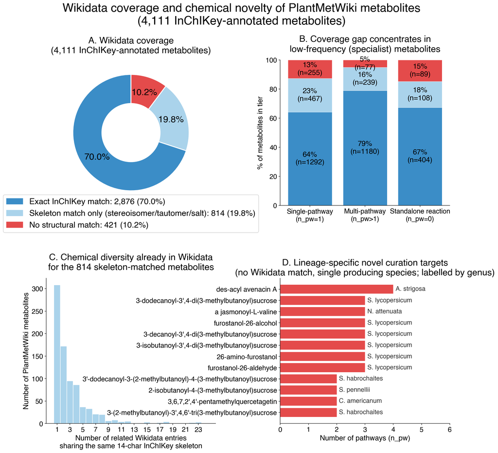

```
Saved figures/output/figures/wikidata_coverage_overlap.{pdf,svg}
```

```python
# ─────────────────────────────────────────────────────────────────────────────
# Figure 6: Wikidata coverage & chemical-novelty overview (panels A-D)
# ─────────────────────────────────────────────────────────────────────────────
import matplotlib.patches as mpatches
import matplotlib.patheffects as pe

sk_map = dict(zip(not_in_wd['inchikey'], not_in_wd['skeleton_match_n']))

def categorize(row):
    if row['in_wikidata']:
        return 'Exact InChIKey\nmatch'
    if sk_map.get(row['inchikey'], 0) > 0:
        return 'Skeleton match only\n(stereoisomer/tautomer/salt)'
    return 'No structural\nmatch'

all_metabolites['coverage_cat'] = all_metabolites.apply(categorize, axis=1)
CAT_ORDER = ['Exact InChIKey\nmatch', 'Skeleton match only\n(stereoisomer/tautomer/salt)', 'No structural\nmatch']
CAT_COLORS = {
    'Exact InChIKey\nmatch': "#3b8dc7",                          # same blue as Figure 1 'With InChIKey'
    'Skeleton match only\n(stereoisomer/tautomer/salt)': "#aad3eb",  # lighter shade of the InChIKey blue
    'No structural\nmatch': "#e44b4b",                          # Figure 1 red
}

fig = plt.figure(figsize=(16, 14.5))
gs = fig.add_gridspec(2, 2, height_ratios=[1.5, 1.5], hspace=0.5, wspace=0.38)

# ── Panel A: donut — legend BELOW, no text on wedges ─────────────────────────
axA = fig.add_subplot(gs[0, 0])
counts_A = all_metabolites['coverage_cat'].value_counts().reindex(CAT_ORDER)
wedges_A, _, autotexts_A = axA.pie(
    counts_A,
    colors=[CAT_COLORS[c] for c in CAT_ORDER],
    labels=None,
    autopct='%1.1f%%',
    startangle=90,
    wedgeprops=dict(width=0.50, edgecolor='white', linewidth=2),
    pctdistance=0.72,
)
for at in autotexts_A:
    at.set_fontsize(20)
    at.set_fontweight('bold')
axA.set_title(
    f'A. Wikidata coverage\n({len(all_metabolites):,} InChIKey-annotated metabolites)',
    fontsize=20, pad=15,
)
handles_A = [
    mpatches.Patch(
        color=CAT_COLORS[c],
        label=f'{c.replace(chr(10), " ")}: {int(counts_A[c]):,} ({100*counts_A[c]/len(all_metabolites):.1f}%)'
    )
    for c in CAT_ORDER
]
axA.legend(
    handles=handles_A, loc='upper center', bbox_to_anchor=(0.5, 0.1),
    fontsize=18, ncol=1, frameon=True, facecolor='white',
    edgecolor='#cccccc', framealpha=0.9,
)

# ── Panel B: stacked bars by pathway-frequency tier ──────────────────────────
axB = fig.add_subplot(gs[0, 1])
TIER_ORDER  = ['single pathway (n_pw=1)', 'multi-pathway (n_pw>1)', 'no PC* pathway (n_pw=0)']
TIER_LABELS = ['Single-pathway\n(n_pw=1)', 'Multi-pathway\n(n_pw>1)', 'Standalone reaction\n(n_pw=0)']
ct = pd.crosstab(all_metabolites['tier'], all_metabolites['coverage_cat'])
ct = ct.reindex(index=TIER_ORDER, columns=CAT_ORDER)
ct_pct = 100 * ct.div(ct.sum(axis=1), axis=0)

bottom = np.zeros(len(ct))
for cat in CAT_ORDER:
    vals = ct_pct[cat].values
    axB.bar(TIER_LABELS, vals, bottom=bottom, color=CAT_COLORS[cat],
            label=cat.replace(chr(10), ' '), edgecolor='white', linewidth=0.5)
    for x, (v, b, n) in enumerate(zip(vals, bottom, ct[cat].values)):
        if v > 5:
            axB.text(x, b + v / 2, f'{v:.0f}%\n(n={n})',
                     ha='center', va='center', fontsize=16, color='black', fontweight='bold')
    bottom += vals
axB.set_ylabel('% of metabolites in tier', fontsize=16)
axB.set_title('B. Coverage gap concentrates in\nlow-frequency (specialist) metabolites', fontsize=20, pad=18)
axB.tick_params(axis='both', labelsize=15)
axB.spines[['top', 'right']].set_visible(False)
axB.set_ylim(0, 100)

# ── Panel C: histogram of skeleton-match counts ───────────────────────────────
axC = fig.add_subplot(gs[1, 0])
sk_counts = not_in_wd.loc[not_in_wd['skeleton_match_n'] > 0, 'skeleton_match_n']
bins = np.arange(1, sk_counts.max() + 2) - 0.5
axC.hist(sk_counts, bins=bins,
         color=CAT_COLORS['Skeleton match only\n(stereoisomer/tautomer/salt)'],
         edgecolor='white')
axC.set_xlabel('Number of related Wikidata entries\nsharing the same 14-char InChIKey skeleton',
               fontsize=16)
axC.set_ylabel('Number of PlantMetWiki metabolites', fontsize=16)
axC.set_title(
    f'C. Chemical diversity already in Wikidata\nfor the {len(sk_counts):,} skeleton-matched metabolites',
    fontsize=20, pad=18,
)
axC.tick_params(axis='both', labelsize=15)
axC.spines[['top', 'right']].set_visible(False)
axC.set_xticks(range(1, sk_counts.max() + 1, max(1, sk_counts.max() // 9)))

# ── Panel D: lineage-specific novel curation targets ─────────────────────────
# Novel scaffolds (no Wikidata skeleton match) produced by exactly ONE annotated
# species — the strongest lineage-specific candidates — ranked by pathway context
# (n_pw). Each bar labelled with the producing genus. This intentionally excludes
# the 0-species reaction intermediates (weaker biosynthetic evidence).
axD = fig.add_subplot(gs[1, 1])
def _abbr_sp(name):
    p = str(name).split(';')[0].split()
    return f"{p[0][0]}. {p[1]}" if len(p) >= 2 else (p[0] if p else '')
_novelD = not_in_wd.loc[(not_in_wd['skeleton_match_n'] == 0) &
                        (not_in_wd['n_species'] == 1)].copy()
top_novel = _novelD.nlargest(12, 'n_pw').sort_values('n_pw')
labels_d = [str(l) for l in top_novel['label']]
bars_d = axD.barh(labels_d, top_novel['n_pw'], color=CAT_COLORS['No structural\nmatch'])
_xmax = max(int(top_novel['n_pw'].max()), 1)
for bar, (_, r) in zip(bars_d, top_novel.iterrows()):
    axD.text(bar.get_width() + _xmax * 0.02, bar.get_y() + bar.get_height() / 2,
             _abbr_sp(r.get('species_name', '')), va='center', fontsize=14,
             fontstyle='italic', color='#333333')
axD.set_xlim(0, _xmax * 1.5)
axD.set_xlabel('Number of pathways (n_pw)', fontsize=16)
axD.set_title(
    'D. Lineage-specific novel curation targets\n'
    '(no Wikidata match, single producing species; labelled by genus)',
    fontsize=20,
)
axD.tick_params(axis='y', labelsize=15)
axD.tick_params(axis='x', labelsize=15)
axD.spines[['top', 'right']].set_visible(False)

fig.suptitle(
    'Wikidata coverage and chemical novelty of PlantMetWiki metabolites\n'
    f'({len(all_metabolites):,} InChIKey-annotated metabolites)',
    fontsize=26, y=1,
)

plt.savefig('figures/output/figures/wikidata_coverage_overlap.pdf', bbox_inches='tight')
plt.savefig('figures/output/figures/wikidata_coverage_overlap.svg', bbox_inches='tight')
plt.show()
print("Saved figures/output/figures/wikidata_coverage_overlap.{pdf,svg}")
```